```python
from IPython.display import Image
import numpy as np
from matplotlib import pyplot as plt
%matplotlib inline
```

# Exact PGT Profiles

Let's just look at the extensive form representation of the game. The parameters are not the same as I described on the phone because that scenario led to ties. These utilities were derived from the same game with different parameters.

Rest assured, MCTS still cannot find the "good" equilibrium in this case.

The $1$'s represent the strategy. This is the outcome we would expect with player 1 earning approx 437 and player 2 earning approx. 218

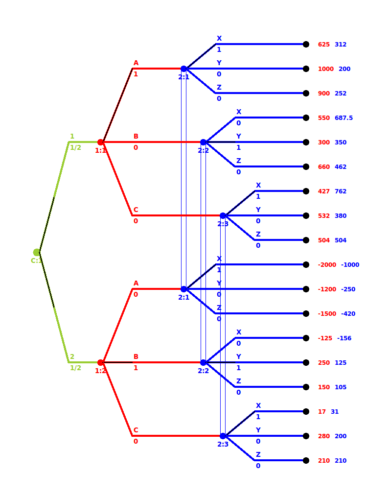

```python
Image('/home/justin/gmetree.png')
```

Now let's look at the "bad" Nash equilibrium in which player 1 earns approx 417 and player 2 earns approx 261.

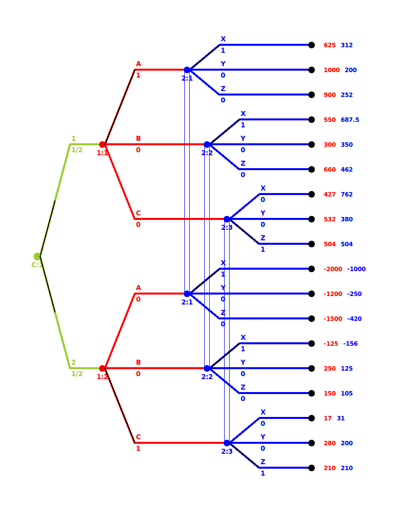

```python
Image('/home/justin/badnet.png')
```

We see that the reason this is a non credible threat is because the follower player threatens to punish the leader if the leader plays "B" in nature state 2.

# Some Code

```python
import itertools
from adsy.display import extended_styles
strat_1 = list(itertools.product(["A", "B", "C"], ["A", "B", "C"]))
strat_2 = list(itertools.product(["X", "Y", "Z"], ["X", "Y", "Z"], ["X", "Y", "Z"]))
extended_styles()
```

Toggle Input

```python
#Utility is a dict keyed by state-player1-player2
utils = {"HAX": (625, 312),
         "HAY": (1000, 200),
         "HAZ": (900, 252),
         "HBX": (550, 687.5),
         "HBY": (300, 350),
         "HBZ": (660, 462),
         "HCX": (427, 762),
         "HCY": (532, 380),
         "HCZ": (504, 504),
         "LAX": (-2000, -1000),
         "LAY": (-1200, -250),
         "LAZ": (-1500, -420),
         "LBX": (-125, -156),
         "LBY": (250, 125),
         "LBZ": (150, 105),
         "LCX": (17, 31),
         "LCY": (280, 200),
         "LCZ": (210, 210)
}
```

```python
mapdict = {"A": 0, "B":1, "C":2}
def EU(p1strat, p2strat, utils=utils, p1top2map=mapdict):
    highukey = "H"+p1strat[0]+p2strat[mapdict[p1strat[0]]]
    lowukey =  "L"+p1strat[1]+p2strat[mapdict[p1strat[1]]]
    p1eu = .5 * utils[highukey][0] + .5 * utils[lowukey][0]
    p2eu = .5 * utils[highukey][1] + .5 * utils[lowukey][1]
    return p1eu, p2eu
```

```python
stratprofiles = list(itertools.product(strat_1, strat_2))
```

```python
def get_intelligence(profile):
    p1strat = profile[0]
    p2strat = profile[1]
    util = EU(p1strat, p2strat)
    #print util
    p1_numalt = float(len(strat_1))
    p2_numalt = float(len(strat_2))
    num_no_betterp1 = 0
    num_no_betterp2 = 0
    for s in strat_1:
        if EU(s, p2strat)[0] <= util[0]:
            num_no_betterp1 +=1
    for s in strat_2:
        if EU(p1strat, s)[1] <= util[1]:
            num_no_betterp2 +=1
    return (num_no_betterp1-1)/(p1_numalt - 1) * (num_no_betterp2 - 1)/(p2_numalt -1)
```

```python
intels = []
for p in stratprofiles:
    intels.append(get_intelligence(p))
```

### Equivalence Class stuff (here untill next heading)

```python
def get_eq_path(profile):
    p1h = profile[0][0]
    p2h = profile[1][mapdict[p1h]]
    p1l = profile[0][1]
    p2l = profile[1][mapdict[p1l]]
    return p1h+p2h+p1l+p2l
```

```python
observed = [get_eq_path(p) for p in stratprofiles]
```

```python
# HERE IS THE NUMBER OF EQUIVALENCE CLASSES
print "The number of equivalence classes is ", len(set(observed))
```

```
The number of equivalence classes is  63
```

```python
eqclassixdict ={}
for ix, o in enumerate(observed):
    if o in eqclassixdict.keys():
        eqclassixdict[o].append(ix)
    else:
        eqclassixdict[o] = [ix]
```

### Note 1: Strategies that give the same on-equilibrium path observations do not necessarily have the same intelligence

Consider player 1's strategy:

- $A$ if 1, $B$ if 2

and the following three profiles by player 2:

- $X$ if $A$, $Y$ if $B$, $X$ if $C$
- $X$ if $A$, $Y$ if $B$, $Y$ if $C$
- $X$ if $A$, $Y$ if $B$, $Z$ if $C$

Of course, these three strategies will give the same observed outcome. In fact, using the first and the third profile for player 2 are both Nash equilibria. (They are the "good" equilibria)

Do why doesn't the second strategy of player 2 give an intelligence of 1? The reason is that if player 2 plays $Y$ when player $1$ plays $C$, then player one will have a higher utility if his strategy has him playing $C$ when the market is state 2.

### Note 2

"Not good" equilibria can be in an equivalence class with other profiles that do not have an intelligence of 1. For example, consider the equivalence class that has player 1 playing $A$ when nature is in state $1$ and $C$ when nature is in state 2. Player 2 plays $X$ when he observes $A$ and $Z$ wgen he observes $C$. Of course there are 3 strategies in this equivalence class. However, two of these strategies do not have intelligence of 1 because player 2 no longer makes a "threat" and therefore player 1 can earn a higher utility by altering his strategy.

### All Intelligences

Player 1 plays $A$ in market state 1, player 1 plays $A$ in market state 2. Player 2 plays $X$ if he observes $A$, $Y$ if he observes $B$ and $Z$ if he observes $C$.

```python
for ix in range(len(stratprofiles)):
    print stratprofiles[ix], intels[ix]
```

```
(('A', 'A'), ('X', 'X', 'X')) 0.0769230769231
(('A', 'A'), ('X', 'X', 'Y')) 0.0769230769231
(('A', 'A'), ('X', 'X', 'Z')) 0.0769230769231
(('A', 'A'), ('X', 'Y', 'X')) 0.0769230769231
(('A', 'A'), ('X', 'Y', 'Y')) 0.0769230769231
(('A', 'A'), ('X', 'Y', 'Z')) 0.0769230769231
(('A', 'A'), ('X', 'Z', 'X')) 0.0384615384615
(('A', 'A'), ('X', 'Z', 'Y')) 0.0384615384615
(('A', 'A'), ('X', 'Z', 'Z')) 0.0384615384615
(('A', 'A'), ('Y', 'X', 'X')) 0.25
(('A', 'A'), ('Y', 'X', 'Y')) 0.25
(('A', 'A'), ('Y', 'X', 'Z')) 0.25
(('A', 'A'), ('Y', 'Y', 'X')) 0.25
(('A', 'A'), ('Y', 'Y', 'Y')) 0.25
(('A', 'A'), ('Y', 'Y', 'Z')) 0.25
(('A', 'A'), ('Y', 'Z', 'X')) 0.25
(('A', 'A'), ('Y', 'Z', 'Y')) 0.25
(('A', 'A'), ('Y', 'Z', 'Z')) 0.25
(('A', 'A'), ('Z', 'X', 'X')) 0.163461538462
(('A', 'A'), ('Z', 'X', 'Y')) 0.163461538462
(('A', 'A'), ('Z', 'X', 'Z')) 0.163461538462
(('A', 'A'), ('Z', 'Y', 'X')) 0.163461538462
(('A', 'A'), ('Z', 'Y', 'Y')) 0.163461538462
(('A', 'A'), ('Z', 'Y', 'Z')) 0.163461538462
(('A', 'A'), ('Z', 'Z', 'X')) 0.163461538462
(('A', 'A'), ('Z', 'Z', 'Y')) 0.163461538462
(('A', 'A'), ('Z', 'Z', 'Z')) 0.163461538462
(('A', 'B'), ('X', 'X', 'X')) 0.230769230769
(('A', 'B'), ('X', 'X', 'Y')) 0.192307692308
(('A', 'B'), ('X', 'X', 'Z')) 0.192307692308
(('A', 'B'), ('X', 'Y', 'X')) 1.0
(('A', 'B'), ('X', 'Y', 'Y')) 0.875
(('A', 'B'), ('X', 'Y', 'Z')) 1.0
(('A', 'B'), ('X', 'Z', 'X')) 0.774038461538
(('A', 'B'), ('X', 'Z', 'Y')) 0.442307692308
(('A', 'B'), ('X', 'Z', 'Z')) 0.552884615385
(('A', 'B'), ('Y', 'X', 'X')) 0.0673076923077
(('A', 'B'), ('Y', 'X', 'Y')) 0.0673076923077
(('A', 'B'), ('Y', 'X', 'Z')) 0.0673076923077
(('A', 'B'), ('Y', 'Y', 'X')) 0.538461538462
```

[output cut: 188 more lines]

```
(('C', 'C'), ('Y', 'Y', 'X')) 0.5
(('C', 'C'), ('Y', 'Y', 'Y')) 0.230769230769
(('C', 'C'), ('Y', 'Y', 'Z')) 0.408653846154
(('C', 'C'), ('Y', 'Z', 'X')) 0.375
(('C', 'C'), ('Y', 'Z', 'Y')) 0.192307692308
(('C', 'C'), ('Y', 'Z', 'Z')) 0.326923076923
(('C', 'C'), ('Z', 'X', 'X')) 0.625
(('C', 'C'), ('Z', 'X', 'Y')) 0.230769230769
(('C', 'C'), ('Z', 'X', 'Z')) 0.408653846154
(('C', 'C'), ('Z', 'Y', 'X')) 0.5
(('C', 'C'), ('Z', 'Y', 'Y')) 0.230769230769
(('C', 'C'), ('Z', 'Y', 'Z')) 0.408653846154
(('C', 'C'), ('Z', 'Z', 'X')) 0.375
(('C', 'C'), ('Z', 'Z', 'Y')) 0.192307692308
(('C', 'C'), ('Z', 'Z', 'Z')) 0.326923076923
```

### "Full Game" Intelligence

1. Calculate the intelligence of s_L and s_F in the usual way, i.e. on-path, and call it IQ(i,s,on-path). While doing that, keep track of all unvisited information sets for each player, i.e. the set of off-path information sets, H_i.
2. For each player i, for each unvisited information set h in H_i, and for each state n in h, calculate the intelligence of s_i in information set h given that the state is n, call this IQ(i,s,n).
3. For each player i, for each unvisited information set h, take the average intelligence across nodes n in h: IQ(i,s,h)=1/|h| * \sum_{n\in h} IQ(i,s,n)
4. Take the average of IQ(i,s,h) across unvisited information sets in H*i: IQ(i,s,off-path) = 1/|H_i| * sum*{h\in H_i} IQ(i,s,h).
5. Calculate IQ(i,s,full-game) = p*IQ(i,s,on-path) + (1-p)*IQ(i,s,off-path), where p is a parameter we control based on the importance of off-path play. Let’s start with something like p=.5.

### Some more code

```python
def get_off_path_info_sets(profile):
    unvisited = set(["A", "B", "C"]) - set(list(profile[0]))
    return unvisited
```

```python
def get_off_path_intel(profile, p=.5):
    unvisited = list(get_off_path_info_sets(profile))
    unvisited_intels = []
    for u in unvisited:
        num_no_better_high = 0.
        num_no_better_low = 0.
        p2s_action = profile[1][mapdict[u]]
        utility_high = utils["H" + u + p2s_action][1]
        utility_low = utils["L" + u + p2s_action][1]
        p2s_other_actions = list(set(["X", "Y", "Z"]) - set(p2s_action))
        for other in p2s_other_actions:
            utility_high_other = utils["H" + u + other][1]
            utility_low_other = utils["L" + u + other][1]
            if utility_high_other <= utility_high:
                num_no_better_high +=1
            if utility_low_other <= utility_low:
                num_no_better_low +=1
        unvisited_intels.append(p * num_no_better_high/2. + (1-p)* num_no_better_low/2.)


    return sum(unvisited_intels)/float(len(unvisited_intels))
```

```python
off_path_intels = [get_off_path_intel(s) for s in stratprofiles]
```

```python
print "Strategy", "                        Intelligence", "              Off Path Intel"
for ix, s in enumerate(stratprofiles):
    print s, '      ', ("%.2f" % intels[ix]), '                    ',  off_path_intels[ix]
```

```
Strategy                         Intelligence               Off Path Intel
(('A', 'A'), ('X', 'X', 'X'))        0.08                      0.5
(('A', 'A'), ('X', 'X', 'Y'))        0.08                      0.375
(('A', 'A'), ('X', 'X', 'Z'))        0.08                      0.625
(('A', 'A'), ('X', 'Y', 'X'))        0.08                      0.5
(('A', 'A'), ('X', 'Y', 'Y'))        0.08                      0.375
(('A', 'A'), ('X', 'Y', 'Z'))        0.08                      0.625
(('A', 'A'), ('X', 'Z', 'X'))        0.04                      0.5
(('A', 'A'), ('X', 'Z', 'Y'))        0.04                      0.375
(('A', 'A'), ('X', 'Z', 'Z'))        0.04                      0.625
(('A', 'A'), ('Y', 'X', 'X'))        0.25                      0.5
(('A', 'A'), ('Y', 'X', 'Y'))        0.25                      0.375
(('A', 'A'), ('Y', 'X', 'Z'))        0.25                      0.625
(('A', 'A'), ('Y', 'Y', 'X'))        0.25                      0.5
(('A', 'A'), ('Y', 'Y', 'Y'))        0.25                      0.375
(('A', 'A'), ('Y', 'Y', 'Z'))        0.25                      0.625
(('A', 'A'), ('Y', 'Z', 'X'))        0.25                      0.5
(('A', 'A'), ('Y', 'Z', 'Y'))        0.25                      0.375
(('A', 'A'), ('Y', 'Z', 'Z'))        0.25                      0.625
(('A', 'A'), ('Z', 'X', 'X'))        0.16                      0.5
(('A', 'A'), ('Z', 'X', 'Y'))        0.16                      0.375
(('A', 'A'), ('Z', 'X', 'Z'))        0.16                      0.625
(('A', 'A'), ('Z', 'Y', 'X'))        0.16                      0.5
(('A', 'A'), ('Z', 'Y', 'Y'))        0.16                      0.375
(('A', 'A'), ('Z', 'Y', 'Z'))        0.16                      0.625
(('A', 'A'), ('Z', 'Z', 'X'))        0.16                      0.5
(('A', 'A'), ('Z', 'Z', 'Y'))        0.16                      0.375
(('A', 'A'), ('Z', 'Z', 'Z'))        0.16                      0.625
(('A', 'B'), ('X', 'X', 'X'))        0.23                      0.5
(('A', 'B'), ('X', 'X', 'Y'))        0.19                      0.25
(('A', 'B'), ('X', 'X', 'Z'))        0.19                      0.75
(('A', 'B'), ('X', 'Y', 'X'))        1.00                      0.5
(('A', 'B'), ('X', 'Y', 'Y'))        0.88                      0.25
(('A', 'B'), ('X', 'Y', 'Z'))        1.00                      0.75
(('A', 'B'), ('X', 'Z', 'X'))        0.77                      0.5
(('A', 'B'), ('X', 'Z', 'Y'))        0.44                      0.25
(('A', 'B'), ('X', 'Z', 'Z'))        0.55                      0.75
(('A', 'B'), ('Y', 'X', 'X'))        0.07                      0.5
(('A', 'B'), ('Y', 'X', 'Y'))        0.07                      0.25
(('A', 'B'), ('Y', 'X', 'Z'))        0.07                      0.75
```

[output cut: 189 more lines]

```
(('C', 'C'), ('Y', 'Y', 'X'))        0.50                      0.5
(('C', 'C'), ('Y', 'Y', 'Y'))        0.23                      0.5
(('C', 'C'), ('Y', 'Y', 'Z'))        0.41                      0.5
(('C', 'C'), ('Y', 'Z', 'X'))        0.38                      0.5
(('C', 'C'), ('Y', 'Z', 'Y'))        0.19                      0.5
(('C', 'C'), ('Y', 'Z', 'Z'))        0.33                      0.5
(('C', 'C'), ('Z', 'X', 'X'))        0.62                      0.5
(('C', 'C'), ('Z', 'X', 'Y'))        0.23                      0.5
(('C', 'C'), ('Z', 'X', 'Z'))        0.41                      0.5
(('C', 'C'), ('Z', 'Y', 'X'))        0.50                      0.5
(('C', 'C'), ('Z', 'Y', 'Y'))        0.23                      0.5
(('C', 'C'), ('Z', 'Y', 'Z'))        0.41                      0.5
(('C', 'C'), ('Z', 'Z', 'X'))        0.38                      0.5
(('C', 'C'), ('Z', 'Z', 'Y'))        0.19                      0.5
(('C', 'C'), ('Z', 'Z', 'Z'))        0.33                      0.5
```

### Note 1

The "good" equilibria do not have off-path intellifences of 1.  
The reason is that the intellegience is the average of the intelligence that are computed by holding the state constant. Therefore, if the optimal action in an off path information set is different for at least two of the states, the off path intelligence will be less than 1.

### Varying q

```python
nasheq_ix = [i for i, x in enumerate(intels) if x == 1]
```

```python
nasheq_profs = [stratprofiles[x] for x in [30,32,56,114]]
```

```python
collections = []
for q in np.arange(0,1,.01):
    singleq = []
    for s in nasheq_profs:
        singleq.append(get_off_path_intel(s, q))
    collections.append(singleq)
```

```python
collections = np.asarray(collections)
```

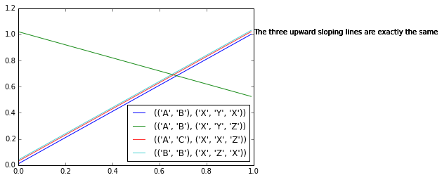

```python
fig, ax = plt.subplots()
for column in range(4):
    dta = collections[:, column]
    ax.plot(np.arange(0,1,.01), dta+(column+1)*.01, label =str(nasheq_profs[column]), alpha=1-.1*column)
    plt.legend(loc =4)
    ax.text(1,1, "The three upward sloping lines are exactly the same")
```

```python
def get_off_path_intel_average_over_states(profile, p=.5):
    unvisited = list(get_off_path_info_sets(profile))
    unvisited_intels = []
    for u in unvisited:
        num_no_better = 0.
        p2s_action = profile[1][mapdict[u]]
        utility = p * utils["H" + u + p2s_action][1] + (1-p) * utils["L" + u + p2s_action][1]
        p2s_other_actions = list(set(["X", "Y", "Z"]) - set(p2s_action))
        for other in p2s_other_actions:
            utility_other  = p * utils["H" + u + other][1] + (1-p) * utils["L" + u + other][1]
            if utility_other <= utility:
                num_no_better +=1
        unvisited_intels.append(num_no_better/2.)
    return sum(unvisited_intels)/float(len(unvisited_intels))
```

```python
collections_average_over_states = []
for q in np.arange(0,1,.01):
    singleq = []
    for s in nasheq_profs:
        singleq.append(get_off_path_intel_average_over_states(s, q))
    collections_average_over_states.append(singleq)
```

```python
collections_average_over_states = np.asarray(collections_average_over_states)
```

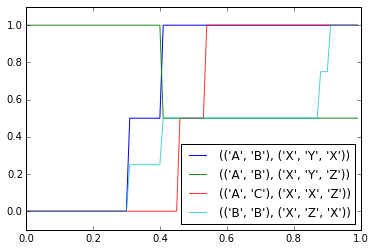

```python
fig, ax = plt.subplots()
for column in range(4):
    dta = collections_average_over_states[:, column]
    ax.plot(np.arange(0,1,.01), dta, label =str(nasheq_profs[column]), alpha=1-.1*column)
    plt.legend(loc =4)
    ax.set_ylim(-.1, 1.1)
```

### PGT With Trembles

```python
mapdict = {"A": 0, "B":1, "C":2}
def EU_with_trembles(p1strat, p2strat, utils=utils, p1top2map=mapdict, p1trembleprob=.2,
                     p2trembleprob=.2, p1tremblestrats=strat_1, p2tremblestrats=strat_2):
    highukey = "H"+p1strat[0]+p2strat[mapdict[p1strat[0]]]
    lowukey =  "L"+p1strat[1]+p2strat[mapdict[p1strat[1]]]
    p1eunotremb = (1-p2trembleprob) * (.5 * utils[highukey][0] + .5 * utils[lowukey][0])
    p2eunotremb = (1-p1trembleprob) * (.5 * utils[highukey][1] + .5 * utils[lowukey][1])
    ### Get the utility that is associated with p2 trembling
    p1epovern = p1trembleprob/float(len(p1tremblestrats) - 1)
    p2epovern = p2trembleprob/float(len(p2tremblestrats) - 1)
    p1tremblingeu = 0 # Utility of p1 when p2 trembles
    p2tremblingeu = 0 # Utility of p2 when p1 trembles
    for s in p2tremblestrats:
        if s != p2strat:
            highukey = "H"+p1strat[0]+s[mapdict[p1strat[0]]]
            lowukey =  "L"+p1strat[1]+s[mapdict[p1strat[1]]]
            p1tremblingeu += p1epovern * (.5 * utils[highukey][0] + .5 * utils[lowukey][0])
    for s in p1tremblestrats:
        if s != p1strat:
            highukey = "H"+s[0]+p2strat[mapdict[s[0]]]
            lowukey =  "L"+s[1]+p2strat[mapdict[s[1]]]
            p2tremblingeu += p2epovern * (.5 * utils[highukey][1] + .5 * utils[lowukey][1])


    return p1eunotremb + p1tremblingeu, p2eunotremb + p2tremblingeu
```

```python
def get_trembling_intelligence(profile):
    p1strat = profile[0]
    p2strat = profile[1]
    util = EU_with_trembles(p1strat, p2strat)
    #print util
    p1_numalt = float(len(strat_1))
    p2_numalt = float(len(strat_2))
    num_no_betterp1 = 0
    num_no_betterp2 = 0
    for s in strat_1:
        if EU_with_trembles(s, p2strat)[0] <= util[0]:
            num_no_betterp1 +=1
    for s in strat_2:
        if EU_with_trembles(p1strat, s)[1] <= util[1]:
            num_no_betterp2 +=1
    return (num_no_betterp1-1)/(p1_numalt - 1) * (num_no_betterp2 - 1)/(p2_numalt -1)
```

```python
trembling_intels = []
for p in stratprofiles:
    trembling_intels.append(get_trembling_intelligence(p))

# Copied form above as convenience
intels = []
for p in stratprofiles:
    intels.append(get_intelligence(p))
```

```python
print "Strategy", "                        Intelligence", "              Trembling Intels"
for ix, s in enumerate(stratprofiles):
    print s, '      ', ("%.2f" % intels[ix]), '                    ',  ("%.2f" % trembling_intels[ix])
```

```
Strategy                         Intelligence               Trembling Intels
(('A', 'A'), ('X', 'X', 'X'))        0.08                      0.07
(('A', 'A'), ('X', 'X', 'Y'))        0.08                      0.01
(('A', 'A'), ('X', 'X', 'Z'))        0.08                      0.04
(('A', 'A'), ('X', 'Y', 'X'))        0.08                      0.05
(('A', 'A'), ('X', 'Y', 'Y'))        0.08                      0.00
(('A', 'A'), ('X', 'Y', 'Z'))        0.08                      0.03
(('A', 'A'), ('X', 'Z', 'X'))        0.04                      0.08
(('A', 'A'), ('X', 'Z', 'Y'))        0.04                      0.02
(('A', 'A'), ('X', 'Z', 'Z'))        0.04                      0.06
(('A', 'A'), ('Y', 'X', 'X'))        0.25                      0.24
(('A', 'A'), ('Y', 'X', 'Y'))        0.25                      0.18
(('A', 'A'), ('Y', 'X', 'Z'))        0.25                      0.21
(('A', 'A'), ('Y', 'Y', 'X'))        0.25                      0.22
(('A', 'A'), ('Y', 'Y', 'Y'))        0.25                      0.17
(('A', 'A'), ('Y', 'Y', 'Z'))        0.25                      0.20
(('A', 'A'), ('Y', 'Z', 'X'))        0.25                      0.25
(('A', 'A'), ('Y', 'Z', 'Y'))        0.25                      0.19
(('A', 'A'), ('Y', 'Z', 'Z'))        0.25                      0.23
(('A', 'A'), ('Z', 'X', 'X'))        0.16                      0.15
(('A', 'A'), ('Z', 'X', 'Y'))        0.16                      0.10
(('A', 'A'), ('Z', 'X', 'Z'))        0.16                      0.12
(('A', 'A'), ('Z', 'Y', 'X'))        0.16                      0.13
(('A', 'A'), ('Z', 'Y', 'Y'))        0.16                      0.09
(('A', 'A'), ('Z', 'Y', 'Z'))        0.16                      0.12
(('A', 'A'), ('Z', 'Z', 'X'))        0.16                      0.16
(('A', 'A'), ('Z', 'Z', 'Y'))        0.16                      0.11
(('A', 'A'), ('Z', 'Z', 'Z'))        0.16                      0.14
(('A', 'B'), ('X', 'X', 'X'))        0.23                      0.27
(('A', 'B'), ('X', 'X', 'Y'))        0.19                      0.14
(('A', 'B'), ('X', 'X', 'Z'))        0.19                      0.20
(('A', 'B'), ('X', 'Y', 'X'))        1.00                      1.00
(('A', 'B'), ('X', 'Y', 'Y'))        0.88                      0.81
(('A', 'B'), ('X', 'Y', 'Z'))        1.00                      0.84
(('A', 'B'), ('X', 'Z', 'X'))        0.77                      0.88
(('A', 'B'), ('X', 'Z', 'Y'))        0.44                      0.71
(('A', 'B'), ('X', 'Z', 'Z'))        0.55                      0.74
(('A', 'B'), ('Y', 'X', 'X'))        0.07                      0.07
(('A', 'B'), ('Y', 'X', 'Y'))        0.07                      0.00
(('A', 'B'), ('Y', 'X', 'Z'))        0.07                      0.03
```

[output cut: 189 more lines]

```
(('C', 'C'), ('Y', 'Y', 'X'))        0.50                      0.46
(('C', 'C'), ('Y', 'Y', 'Y'))        0.23                      0.17
(('C', 'C'), ('Y', 'Y', 'Z'))        0.41                      0.43
(('C', 'C'), ('Y', 'Z', 'X'))        0.38                      0.38
(('C', 'C'), ('Y', 'Z', 'Y'))        0.19                      0.19
(('C', 'C'), ('Y', 'Z', 'Z'))        0.33                      0.33
(('C', 'C'), ('Z', 'X', 'X'))        0.62                      0.53
(('C', 'C'), ('Z', 'X', 'Y'))        0.23                      0.10
(('C', 'C'), ('Z', 'X', 'Z'))        0.41                      0.31
(('C', 'C'), ('Z', 'Y', 'X'))        0.50                      0.40
(('C', 'C'), ('Z', 'Y', 'Y'))        0.23                      0.09
(('C', 'C'), ('Z', 'Y', 'Z'))        0.41                      0.35
(('C', 'C'), ('Z', 'Z', 'X'))        0.38                      0.33
(('C', 'C'), ('Z', 'Z', 'Y'))        0.19                      0.12
(('C', 'C'), ('Z', 'Z', 'Z'))        0.33                      0.27
```

It does separate some of the equilibria but it also gives non-intelligence 1 profiles trembling intelligence of 1.

Some thing to consider:

- USing trembles will likely increase the computing necessity because we are adding an extra element of randomness
- Do we just use the trembling intelligences or do we combine them with the regular intelligence?
- How does the "separating power" of the tremble work when we consider different payoffs and action space?
  - For example, a strategy for player 1 that is in the "good" equilibrium for player 1 might be very vulnerable to an (unlikely) tremble from player 2. He might have a better strategy that he could play that would "hedge" against the tremble. THis would lower the trembling intelligence of player 1's strategy

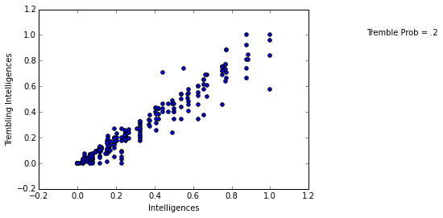

```python
plt.scatter(intels, trembling_intels)
plt.xlabel("Intelligences")
plt.ylabel("Trembling Intelligences")
plt.text(1.5,1, "Tremble Prob = .2")
```

### To keep in mind

We are doing these experiments on games with imperfect information. THe results may be clouded. However, this is something we will eventually need to think about as SFT-Nets are generally games of imperfect information (the state of nature is not know to all players at the time of action). `